# Readme for chicagocrime package

## Introduction

The `chicagocrime` package allows access to multiple processes. For classification, it allows:

- The fitting of a logistic regression model as an `lr` class
- Predict from the `lr` model; one of ‘predictions’, ‘predicted probabilities’ and ‘predicted values’
- Producing mean squared error (MSE) and average log score diagnostics from an `lr` model
- Performing cross validation on an `lr` model
- Plotting a Recever Operating Characteristic (ROC) curve and outputting the Area Under Curve (AUC) diagnostic for an `lr` model

The package also allows access to several data sets, which are

- The crimes data from the city of Chicago data portal, from 2001 to 2019
- Chicago census data from 2010
- Chicago population data
- Police station locations in Chicago

There are also functions that modify and clean the data. These are

- Pre-process the data, removing outliers and missing entries
- Format the data, by adding census, police station and population data

## Data

To load the data, you can use the function `data`, and choose one of `all_crime`, `sub_all_crime`, `census`, `police_stations` or `chicago_population`. The data frame `all_crime` is very large, with 6,336,525 rows and 14 columns. Most work is performed on `sub_all_crime`, a randomly shuffled subset of `all_crime`, with 50,000 rows and 14 columns. For this readme, we will use the subsetted data.

First, we load the package, load in the data, and clean and format it.

```r
library(chicagocrime)
data(sub_all_crime)
sub_all_crime = cleanData(sub_all_crime)
sub_all_crime = formatData(sub_all_crime)
```

```
## Appending census data
```

```
## Loading police station data
## Joining nearest police stations
## Joining nearest population totals
## Done
```

When fitting, we can also split our data into a training set and a testing set. For this example, we will split the final 20% of the data set off as a testing set. Since the data is already shuffled, we do not need to shuffle it here.

```r
cut = round(0.8*nrow(sub_all_crime))
training_set = sub_all_crime[1:cut,]
testing_set = sub_all_crime[(cut+1):nrow(sub_all_crime),]
```

## Logistic Regression

To implement logistic regression, you may use the function `lr`, and specify two arguments; `formula` and `data`. Respectively, these are a symbolic description of the model to be fitted, and the data frame which the formula corresponds to. A simple model with minimial covariates is fit as

```r
fit = lr(Arrest ~ Year + `HARDSHIP INDEX` + `Primary Type`, data = training_set)
```

The `print` function will show covariate estimates for this model.

```r
print(fit)
```

```
##
## Logistic Regression model
## _________________________
## Coefficients:
##      Intercept        Year `HARDSHIP INDEX` `Primary Type`BATTERY
## [1,]  44.72076 -0.02283447     -0.001786314            0.08613083
##      `Primary Type`BURGLARY `Primary Type`CRIMINAL DAMAGE
## [1,]              -1.586049                     -1.381302
##      `Primary Type`CRIMINAL TRESPASS `Primary Type`DECEPTIVE PRACTICE
## [1,]                        2.210048                       -0.2855757
##      `Primary Type`MOTOR VEHICLE THEFT `Primary Type`NARCOTICS
## [1,]                         -1.269238                6.398471
##      `Primary Type`OTHER OFFENSE `Primary Type`PROSTITUTION
## [1,]                  -0.2655222                   6.616507
##      `Primary Type`ROBBERY `Primary Type`THEFT `Primary Type`WEAPONS VIOLATION
## [1,]             -0.925456          -0.8561983                        2.531627
## Log-likelihood value:  -13711.88
```

And to predict from this model also, the `predict` function is used, with different specification of what output to produce. To produce training set predictions, no other arguments need to be specified to `predict`.

```r
p_preds = predict(fit, type="preds")
p_probs = predict(fit, type="probs")
p_vals = predict(fit, type="vals")
```

The `p_preds` vector is be a vector of in-sample predictions, i.e. a vector of 0’s and 1’s. `p_probs` is a vector of probabilities for predicting the positive class, i.e. probability of predicting an arrest (so that `1-p_probs` will be a vector of probabilities for predicting the negative class). Finally, `p_vals` is a vector formed from multiplying the model coefficients against the model matrix formed during fitting, and no other processing. We can inspect these.

```r
table(p_preds)
```

```
## p_preds
##     0     1
## 32547  6104
```

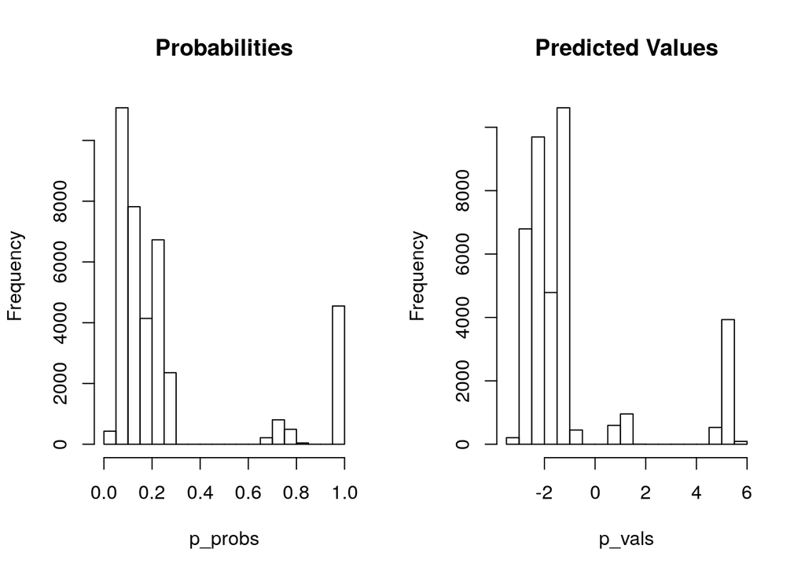

```r
par(mfrow=c(1,2))
hist(p_probs, main = "Probabilities")
hist(p_vals, main = "Predicted Values")
```

These predictions are the basis for providing diagnostics in the form of MSE, log score and AUC. Since MSE is a simple diagnostic, we can simply code

```r
mean((p_preds - training_set$Arrest)^2, na.rm=TRUE)
```

```
## [1] 0.1306305
```

For log score and AUC, we can use the functions `roc.lr` and `log_score`. Since the ROC curve is also a plotting diagnostic, we can specify the argument `plot=TRUE` or `plot=FALSE` to include the plot (and the AUC), or just the AUC. The `roc.lr` function takes the argument of the model fit, whereas `log_score` only needs the prediction and the actual response.

```r
log_score(p_probs, training_set$Arrest)
```

```
## [1] 2.202114
```

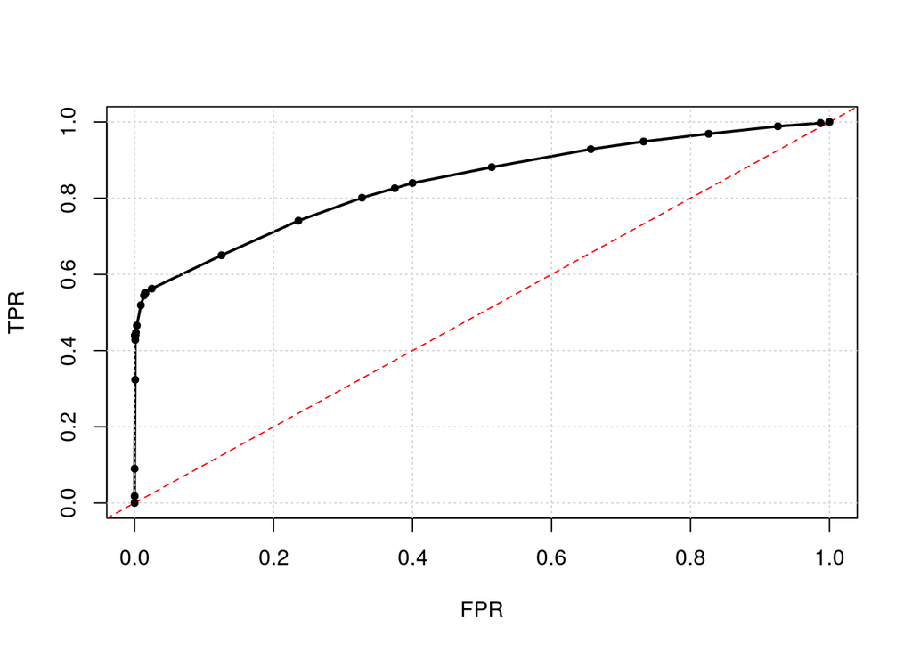

```
## [1] 0.8403321
```

```r
roc.lr(fit, plot = TRUE)
```